# PML Project–Prediction of Weightlifting type by Motion Measurement

### Summary

This is the course project in the Practical Machine Learning course on Coursera. The data are the WLE data set from Velloso, E.; Bulling, A.; Gellersen, H.; Ugulino, W.; Fuks, H. Qualitative Activity Recognition of Weight Lifting Exercises. Proceedings of 4th International Conference in Cooperation with SIGCHI (Augmented Human ’13) . Stuttgart, Germany: ACM SIGCHI, 2013. In this project, I choose relevant variables based on exploratory plots and choose a suitable model using a subset of data. Then I re-derive the model using more data and validate its accuracy. ### Loading Data and Packages For simplicity I downloaded data to local storage and load from there.

```r
pml <- read.csv("pml-training.csv")
pml_test <- read.csv("pml-testing.csv")
library(ggplot2)
library(cowplot)
library(caret)
library(parallel)
library(doParallel)
```

### Data Cleaning and Exploratory analysis

```r
dim(pml)
```

```
## [1] 19622   160
```

```r
dim(pml_test)
```

```
## [1]  20 160
```

```r
colnames(pml)[!colnames(pml)==colnames(pml_test)]
```

```
## [1] "classe"
```

```r
colnames(pml_test)[!colnames(pml)==colnames(pml_test)]
```

```
## [1] "problem_id"
```

The test set and the training set contain the same number of variables. In the training set the classe variable is the result and it is replaced by the problem_id in the testing set.

```r
sum(colSums(is.na(pml))>0)
```

```
## [1] 67
```

```r
sum(colSums(is.na(pml_test))>0)
```

```
## [1] 100
```

There are many variables within each set with NAs. Further

```r
sum(colSums(is.na(pml_test))==dim(pml_test)[1])
```

```
## [1] 100
```

The variables with NAs in the testing set are only NAs for all 20 observations. This means I can use the testing set to select columns with no NAs for both datasets:

```r
pml <- pml[colSums(!is.na(pml_test))>0]
pml_test <- pml_test[colSums(!is.na(pml_test))>0]
sum(colSums(is.na(pml))>0)
```

```
## [1] 0
```

Now no variable in the training or testing sets contains NAs. The training set can be passed to machine learning modeling. Before that, it is necessary to take a look at how these variables are related to each other and remove useless, redundant or interfering variables.

```r
colnames(pml)
```

```
##  [1] "X"                    "user_name"            "raw_timestamp_part_1"
##  [4] "raw_timestamp_part_2" "cvtd_timestamp"       "new_window"
##  [7] "num_window"           "roll_belt"            "pitch_belt"
## [10] "yaw_belt"             "total_accel_belt"     "gyros_belt_x"
## [13] "gyros_belt_y"         "gyros_belt_z"         "accel_belt_x"
## [16] "accel_belt_y"         "accel_belt_z"         "magnet_belt_x"
## [19] "magnet_belt_y"        "magnet_belt_z"        "roll_arm"
## [22] "pitch_arm"            "yaw_arm"              "total_accel_arm"
## [25] "gyros_arm_x"          "gyros_arm_y"          "gyros_arm_z"
## [28] "accel_arm_x"          "accel_arm_y"          "accel_arm_z"
## [31] "magnet_arm_x"         "magnet_arm_y"         "magnet_arm_z"
## [34] "roll_dumbbell"        "pitch_dumbbell"       "yaw_dumbbell"
## [37] "total_accel_dumbbell" "gyros_dumbbell_x"     "gyros_dumbbell_y"
## [40] "gyros_dumbbell_z"     "accel_dumbbell_x"     "accel_dumbbell_y"
## [43] "accel_dumbbell_z"     "magnet_dumbbell_x"    "magnet_dumbbell_y"
## [46] "magnet_dumbbell_z"    "roll_forearm"         "pitch_forearm"
## [49] "yaw_forearm"          "total_accel_forearm"  "gyros_forearm_x"
## [52] "gyros_forearm_y"      "gyros_forearm_z"      "accel_forearm_x"
## [55] "accel_forearm_y"      "accel_forearm_z"      "magnet_forearm_x"
## [58] "magnet_forearm_y"     "magnet_forearm_z"     "classe"
```

```r
colnames(pml)[!(sapply(pml, class)=="numeric" | sapply(pml, class)=="integer")]
```

```
## [1] "user_name"      "cvtd_timestamp" "new_window"     "classe"
```

In the remaining 60 variables, classe is the result. Variables 1-7 are more registry related and some of them are not numbers. Variables 8-59 are measured metrics by equipment.

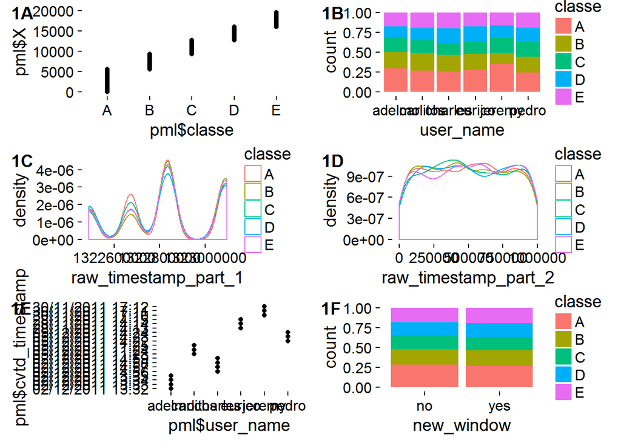

```r
p1 <- qplot(pml$classe, pml$X)
p2 <- ggplot(data=pml, aes(user_name)) + geom_bar(aes(fill=classe), position = "fill")
p3 <- ggplot(data=pml, aes(raw_timestamp_part_1, colour=classe)) + geom_density()
p4 <- ggplot(data=pml, aes(raw_timestamp_part_2, colour=classe)) + geom_density()
p5 <- qplot(pml$user_name, pml$cvtd_timestamp)
p6 <- ggplot(data=pml, aes(new_window)) + geom_bar(aes(fill=classe), position = "fill")
plot_grid(p1, p2, p3, p4, p5, p6, labels=c("1A", "1B", "1C", "1D", "1E", "1F"), ncol = 2, nrow = 3)
```

Fig.1A shows the relationship between X and classe. X could be a good predictor. However, X in the testing set shows that it is just for serial number. So the correlation in Fig.A is just since classe is ordered and followed by X.

```r
pml_test$X
```

```
##  [1]  1  2  3  4  5  6  7  8  9 10 11 12 13 14 15 16 17 18 19 20
```

Fig.1B shows that all users did similar proportion of motions. This also applies to the new_window variable in Fig.1F. Figs.1C&1D show the two raw timestamp variables are not good predictors. Fig.1E shows that the variable cvtd_timestamp is dependent on users, so it is not a good predictor.

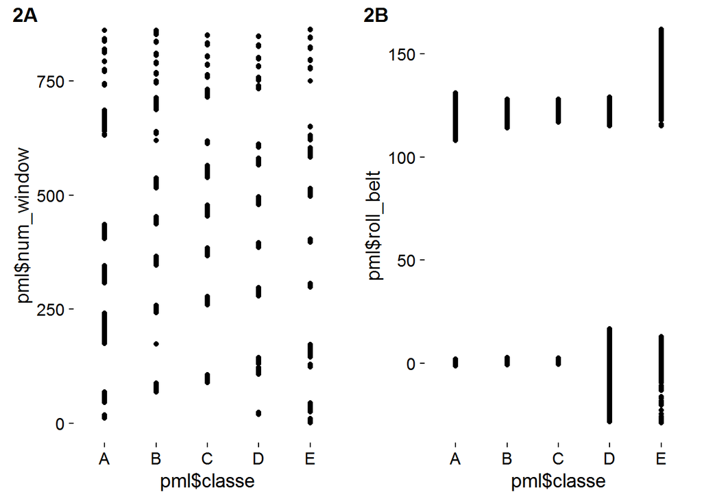

```r
p1 <- qplot(pml$classe, pml$num_window)
p2 <- qplot(pml$classe, pml$roll_belt)
plot_grid(p1, p2, labels=c("2A", "2B"), ncol = 2, nrow = 1)
```

By contrast, the other variables could be predictors as shown in Fig.2A&2B. Therefore, I will use Variables 7 to 59 to predict classe.

```r
pml <- pml[,-(1:6)]
pml_test <- pml_test[,-(1:6)]
```

### Model Selection and Construction

Since the predicted variable is categorical, I will compare radom forest versus boosted trees. I will use a small subset of all observations to make this comparison. To further decrease run time, I will use parallel computing and 5 fold cross validation suggested by the mentors.

```r
set.seed(1)
cluster <- makeCluster(detectCores() - 1)
registerDoParallel(cluster)
fitControl <- trainControl(method = "cv", number = 5, allowParallel = TRUE)
inComparison <- createDataPartition(pml$classe, p = 0.1, list=FALSE)
pmlCom <- pml[inComparison,]
inTrainCom <- createDataPartition(pmlCom$classe, p = 0.5, list=FALSE)
pmlCom_training <- pmlCom[inTrainCom,]
pmlCom_testing <- pmlCom[-inTrainCom,]
rfCom <- train(classe~., method="rf", data=pmlCom_training, trControl=fitControl)
gbmCom <- train(classe~., method="gbm", data=pmlCom_training, trControl=fitControl, verbose=FALSE)
```

The in and out of sample errors are as follows:

```r
confusionMatrix(predict(rfCom, pmlCom_training), pmlCom_training$classe)$overall[1]
```

```
## Accuracy
##        1
```

```r
confusionMatrix(predict(gbmCom, pmlCom_training), pmlCom_training$classe)$overall[1]
```

```
## Accuracy
##        1
```

```r
confusionMatrix(predict(rfCom, pmlCom_testing), pmlCom_testing$classe)$overall[1]
```

```
##  Accuracy
## 0.9347604
```

```r
confusionMatrix(predict(gbmCom, pmlCom_testing), pmlCom_testing$classe)$overall[1]
```

```
##  Accuracy
## 0.9123344
```

Although both models have perfect in-sample prediction, the random forest model has better out-of-sample prediction. So I will apply it to the large data set.

```r
inTrain <- createDataPartition(pml$classe, p = 0.75, list=FALSE)
pml_training <- pml[inTrain,]
pml_testing <- pml[-inTrain,]
rfmod <- train(classe~., method="rf", data=pml_training, trControl=fitControl)
confusionMatrix(predict(rfmod, pml_testing), pml_testing$classe)$overall[1]
```

```
##  Accuracy
## 0.9979608
```

```r
stopCluster(cluster)
```

The out-of-sample accuracy is over 0.99.

### Prediction

Using this model, the predicted result in the testing set is:

```r
predict(rfmod, pml_test)
```

```
##  [1] B A B A A E D B A A B C B A E E A B B B
## Levels: A B C D E
```